# Risk Factor Analysis

## Outcome Variable

**Outcome Variable:** stunted

## Predictor Variables

**Intervention Variable:** earlybf

**Adjustment Set:**

unadjusted

## Stratifying Variables

The analysis was stratified on these variable(s):

- agecat
- studyid
- country

## Data Summary

| agecat | studyid | country | earlybf | stunted | n_cell | n |
| --- | --- | --- | --- | --- | --- | --- |
| Birth | ki0047075b-MAL-ED | BANGLADESH | 0 | 0 | 75 | 256 |
| Birth | ki0047075b-MAL-ED | BANGLADESH | 0 | 1 | 22 | 256 |
| Birth | ki0047075b-MAL-ED | BANGLADESH | 1 | 0 | 134 | 256 |
| Birth | ki0047075b-MAL-ED | BANGLADESH | 1 | 1 | 25 | 256 |
| Birth | ki0047075b-MAL-ED | BRAZIL | 0 | 0 | 94 | 191 |
| Birth | ki0047075b-MAL-ED | BRAZIL | 0 | 1 | 14 | 191 |
| Birth | ki0047075b-MAL-ED | BRAZIL | 1 | 0 | 76 | 191 |
| Birth | ki0047075b-MAL-ED | BRAZIL | 1 | 1 | 7 | 191 |
| Birth | ki0047075b-MAL-ED | INDIA | 0 | 0 | 66 | 205 |
| Birth | ki0047075b-MAL-ED | INDIA | 0 | 1 | 15 | 205 |
| Birth | ki0047075b-MAL-ED | INDIA | 1 | 0 | 106 | 205 |
| Birth | ki0047075b-MAL-ED | INDIA | 1 | 1 | 18 | 205 |
| Birth | ki0047075b-MAL-ED | NEPAL | 0 | 0 | 83 | 173 |
| Birth | ki0047075b-MAL-ED | NEPAL | 0 | 1 | 11 | 173 |
| Birth | ki0047075b-MAL-ED | NEPAL | 1 | 0 | 72 | 173 |
| Birth | ki0047075b-MAL-ED | NEPAL | 1 | 1 | 7 | 173 |
| Birth | ki0047075b-MAL-ED | PERU | 0 | 0 | 61 | 287 |
| Birth | ki0047075b-MAL-ED | PERU | 0 | 1 | 12 | 287 |
| Birth | ki0047075b-MAL-ED | PERU | 1 | 0 | 192 | 287 |
| Birth | ki0047075b-MAL-ED | PERU | 1 | 1 | 22 | 287 |
| Birth | ki0047075b-MAL-ED | SOUTH AFRICA | 0 | 0 | 78 | 247 |
| Birth | ki0047075b-MAL-ED | SOUTH AFRICA | 0 | 1 | 14 | 247 |
| Birth | ki0047075b-MAL-ED | SOUTH AFRICA | 1 | 0 | 143 | 247 |
| Birth | ki0047075b-MAL-ED | SOUTH AFRICA | 1 | 1 | 12 | 247 |
| Birth | ki0047075b-MAL-ED | TANZANIA, UNITED REPUBLIC OF | 0 | 0 | 9 | 123 |
| Birth | ki0047075b-MAL-ED | TANZANIA, UNITED REPUBLIC OF | 0 | 1 | 3 | 123 |
| Birth | ki0047075b-MAL-ED | TANZANIA, UNITED REPUBLIC OF | 1 | 0 | 96 | 123 |
| Birth | ki0047075b-MAL-ED | TANZANIA, UNITED REPUBLIC OF | 1 | 1 | 15 | 123 |
| Birth | ki1000109-EE | PAKISTAN | 0 | 0 | 1 | 2 |
| Birth | ki1000109-EE | PAKISTAN | 0 | 1 | 0 | 2 |

[output cut: 126 more lines]

The following strata were considered:

- agecat: 24 months, studyid: ki0047075b-MAL-ED, country: BANGLADESH
- agecat: 24 months, studyid: ki0047075b-MAL-ED, country: BRAZIL
- agecat: 24 months, studyid: ki0047075b-MAL-ED, country: INDIA
- agecat: 24 months, studyid: ki0047075b-MAL-ED, country: NEPAL
- agecat: 24 months, studyid: ki0047075b-MAL-ED, country: PERU
- agecat: 24 months, studyid: ki0047075b-MAL-ED, country: SOUTH AFRICA
- agecat: 24 months, studyid: ki0047075b-MAL-ED, country: TANZANIA, UNITED REPUBLIC OF
- agecat: 24 months, studyid: ki1017093c-NIH-Crypto, country: BANGLADESH
- agecat: 24 months, studyid: ki1113344-GMS-Nepal, country: NEPAL
- agecat: 24 months, studyid: ki1126311-ZVITAMBO, country: ZIMBABWE
- agecat: 24 months, studyid: kiGH5241-JiVitA-3, country: BANGLADESH
- agecat: 24 months, studyid: kiGH5241-JiVitA-4, country: BANGLADESH
- agecat: 6 months, studyid: ki0047075b-MAL-ED, country: BANGLADESH
- agecat: 6 months, studyid: ki0047075b-MAL-ED, country: BRAZIL
- agecat: 6 months, studyid: ki0047075b-MAL-ED, country: INDIA
- agecat: 6 months, studyid: ki0047075b-MAL-ED, country: NEPAL
- agecat: 6 months, studyid: ki0047075b-MAL-ED, country: PERU
- agecat: 6 months, studyid: ki0047075b-MAL-ED, country: SOUTH AFRICA
- agecat: 6 months, studyid: ki0047075b-MAL-ED, country: TANZANIA, UNITED REPUBLIC OF
- agecat: 6 months, studyid: ki1000109-EE, country: PAKISTAN
- agecat: 6 months, studyid: ki1000304b-SAS-CompFeed, country: INDIA
- agecat: 6 months, studyid: ki1017093c-NIH-Crypto, country: BANGLADESH
- agecat: 6 months, studyid: ki1113344-GMS-Nepal, country: NEPAL
- agecat: 6 months, studyid: ki1126311-ZVITAMBO, country: ZIMBABWE
- agecat: 6 months, studyid: kiGH5241-JiVitA-3, country: BANGLADESH
- agecat: 6 months, studyid: kiGH5241-JiVitA-4, country: BANGLADESH
- agecat: Birth, studyid: ki0047075b-MAL-ED, country: BANGLADESH
- agecat: Birth, studyid: ki0047075b-MAL-ED, country: BRAZIL
- agecat: Birth, studyid: ki0047075b-MAL-ED, country: INDIA
- agecat: Birth, studyid: ki0047075b-MAL-ED, country: NEPAL
- agecat: Birth, studyid: ki0047075b-MAL-ED, country: PERU
- agecat: Birth, studyid: ki0047075b-MAL-ED, country: SOUTH AFRICA
- agecat: Birth, studyid: ki0047075b-MAL-ED, country: TANZANIA, UNITED REPUBLIC OF
- agecat: Birth, studyid: ki1000109-EE, country: PAKISTAN
- agecat: Birth, studyid: ki1000304b-SAS-CompFeed, country: INDIA
- agecat: Birth, studyid: ki1017093c-NIH-Crypto, country: BANGLADESH
- agecat: Birth, studyid: ki1126311-ZVITAMBO, country: ZIMBABWE
- agecat: Birth, studyid: kiGH5241-JiVitA-3, country: BANGLADESH
- agecat: Birth, studyid: kiGH5241-JiVitA-4, country: BANGLADESH

### Dropped Strata

Some strata were dropped due to rare outcomes:

- agecat: Birth, studyid: ki0047075b-MAL-ED, country: TANZANIA, UNITED REPUBLIC OF
- agecat: Birth, studyid: ki1000109-EE, country: PAKISTAN
- agecat: Birth, studyid: ki1000304b-SAS-CompFeed, country: INDIA
- agecat: Birth, studyid: ki1017093c-NIH-Crypto, country: BANGLADESH
- agecat: 6 months, studyid: ki0047075b-MAL-ED, country: BRAZIL
- agecat: 6 months, studyid: ki0047075b-MAL-ED, country: NEPAL
- agecat: 24 months, studyid: ki0047075b-MAL-ED, country: BRAZIL
- agecat: 24 months, studyid: kiGH5241-JiVitA-3, country: BANGLADESH

## Methods Detail

We’re interested in the causal parameters $E[Y_a]$ for all values of $a \in \mathcal{A}$. These parameters represent the mean outcome if, possibly contrary to fact, we intervened to set all units to have $A=a$. Under the randomization and positivity assumptions, these are identified by the statistical parameters $\psi_a=E_W[E_{Y|A,W}(Y|A=a,W)]$. In addition, we’re interested in the mean of $Y$, $E[Y]$ under no intervention (the observed mean). We will estimate these parameters by using SuperLearner to fit the relevant likelihood factors – $E_{Y|A,W}(Y|A=a,W)$ and $p(A=a|W)$, and then updating our likelihood fit using a joint TMLE.

For unadjusted analyses ($W=\{\}$), initial likelihoods were estimated using Lrnr_glm to estimate the simple $E(Y|A)$ and Lrnr_mean to estimate $p(A)$. For adjusted analyses, a small library containing Lrnr_glmnet, Lrnr_xgboost, and Lrnr_mean was used.

Having estimated these parameters, we will then use the delta method to estimate relative risks and attributable risks relative to a prespecified baseline level of $A$.

# Results Detail

## Results Plots

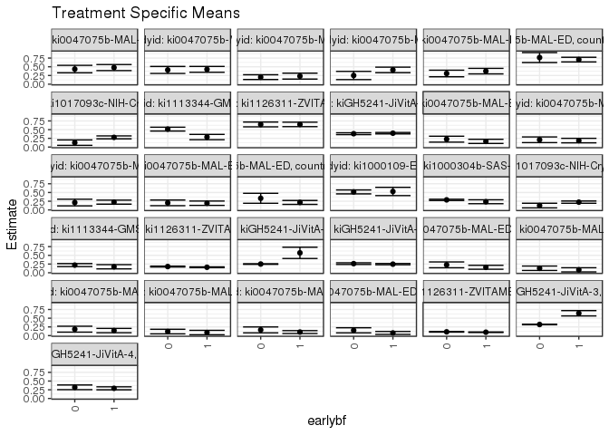

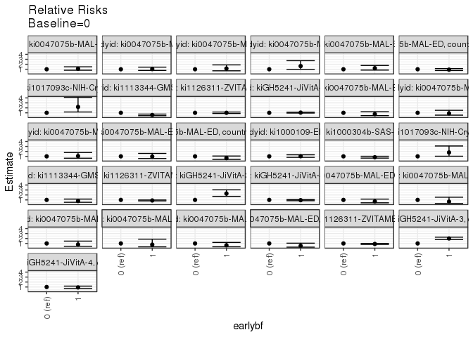

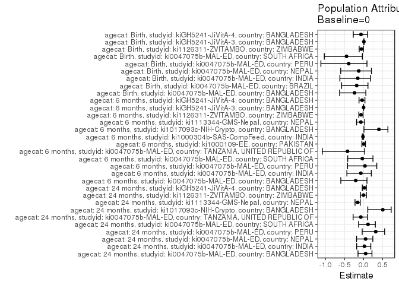

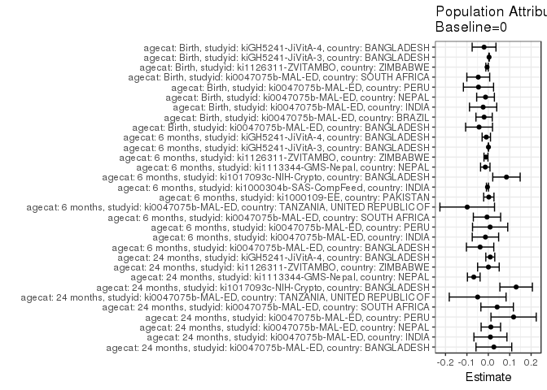

## Results Table

### Parameter: TSM

| agecat | studyid | country | intervention_level | baseline_level | estimate | ci_lower | ci_upper |
| --- | --- | --- | --- | --- | --- | --- | --- |
| Birth | ki0047075b-MAL-ED | BANGLADESH | 0 | NA | 0.2268041 | 0.1433049 | 0.3103033 |
| Birth | ki0047075b-MAL-ED | BANGLADESH | 1 | NA | 0.1572327 | 0.1005403 | 0.2139251 |
| Birth | ki0047075b-MAL-ED | BRAZIL | 0 | NA | 0.1296296 | 0.0661140 | 0.1931452 |
| Birth | ki0047075b-MAL-ED | BRAZIL | 1 | NA | 0.0843373 | 0.0243960 | 0.1442787 |
| Birth | ki0047075b-MAL-ED | INDIA | 0 | NA | 0.1851852 | 0.1003844 | 0.2699860 |
| Birth | ki0047075b-MAL-ED | INDIA | 1 | NA | 0.1451613 | 0.0830076 | 0.2073149 |
| Birth | ki0047075b-MAL-ED | NEPAL | 0 | NA | 0.1170213 | 0.0518509 | 0.1821917 |
| Birth | ki0047075b-MAL-ED | NEPAL | 1 | NA | 0.0886076 | 0.0257610 | 0.1514542 |
| Birth | ki0047075b-MAL-ED | PERU | 0 | NA | 0.1643836 | 0.0792154 | 0.2495517 |
| Birth | ki0047075b-MAL-ED | PERU | 1 | NA | 0.1028037 | 0.0620425 | 0.1435650 |
| Birth | ki0047075b-MAL-ED | SOUTH AFRICA | 0 | NA | 0.1521739 | 0.0786280 | 0.2257198 |
| Birth | ki0047075b-MAL-ED | SOUTH AFRICA | 1 | NA | 0.0774194 | 0.0352604 | 0.1195783 |
| Birth | ki1126311-ZVITAMBO | ZIMBABWE | 0 | NA | 0.1087107 | 0.1006898 | 0.1167316 |
| Birth | ki1126311-ZVITAMBO | ZIMBABWE | 1 | NA | 0.0978111 | 0.0906075 | 0.1050148 |
| Birth | kiGH5241-JiVitA-3 | BANGLADESH | 0 | NA | 0.3197786 | 0.3121413 | 0.3274158 |
| Birth | kiGH5241-JiVitA-3 | BANGLADESH | 1 | NA | 0.6415094 | 0.5652183 | 0.7178006 |
| Birth | kiGH5241-JiVitA-4 | BANGLADESH | 0 | NA | 0.3203125 | 0.2529859 | 0.3876391 |
| Birth | kiGH5241-JiVitA-4 | BANGLADESH | 1 | NA | 0.2915194 | 0.2488609 | 0.3341780 |
| 6 months | ki0047075b-MAL-ED | BANGLADESH | 0 | NA | 0.2258065 | 0.1406522 | 0.3109607 |
| 6 months | ki0047075b-MAL-ED | BANGLADESH | 1 | NA | 0.1632653 | 0.1033915 | 0.2231391 |
| 6 months | ki0047075b-MAL-ED | INDIA | 0 | NA | 0.2083333 | 0.1269220 | 0.2897447 |
| 6 months | ki0047075b-MAL-ED | INDIA | 1 | NA | 0.1857143 | 0.1211612 | 0.2502674 |
| 6 months | ki0047075b-MAL-ED | PERU | 0 | NA | 0.2112676 | 0.1161421 | 0.3063931 |
| 6 months | ki0047075b-MAL-ED | PERU | 1 | NA | 0.2227723 | 0.1652847 | 0.2802599 |
| 6 months | ki0047075b-MAL-ED | SOUTH AFRICA | 0 | NA | 0.2021277 | 0.1207821 | 0.2834733 |
| 6 months | ki0047075b-MAL-ED | SOUTH AFRICA | 1 | NA | 0.1923077 | 0.1303383 | 0.2542771 |
| 6 months | ki0047075b-MAL-ED | TANZANIA, UNITED REPUBLIC OF | 0 | NA | 0.3333333 | 0.1904775 | 0.4761892 |
| 6 months | ki0047075b-MAL-ED | TANZANIA, UNITED REPUBLIC OF | 1 | NA | 0.2146341 | 0.1583174 | 0.2709509 |
| 6 months | ki1000109-EE | PAKISTAN | 0 | NA | 0.5164474 | 0.4601963 | 0.5726984 |
| 6 months | ki1000109-EE | PAKISTAN | 1 | NA | 0.5294118 | 0.4106175 | 0.6482060 |
| 6 months | ki1000304b-SAS-CompFeed | INDIA | 0 | NA | 0.2883683 | 0.2709758 | 0.3057609 |
| 6 months | ki1000304b-SAS-CompFeed | INDIA | 1 | NA | 0.2346939 | 0.1781778 | 0.2912099 |
| 6 months | ki1017093c-NIH-Crypto | BANGLADESH | 0 | NA | 0.1250000 | 0.0587973 | 0.1912027 |
| 6 months | ki1017093c-NIH-Crypto | BANGLADESH | 1 | NA | 0.2229402 | 0.1901286 | 0.2557519 |
| 6 months | ki1113344-GMS-Nepal | NEPAL | 0 | NA | 0.2200557 | 0.1771589 | 0.2629525 |
| 6 months | ki1113344-GMS-Nepal | NEPAL | 1 | NA | 0.1721854 | 0.1119086 | 0.2324623 |
| 6 months | ki1126311-ZVITAMBO | ZIMBABWE | 0 | NA | 0.1783927 | 0.1655176 | 0.1912678 |
| 6 months | ki1126311-ZVITAMBO | ZIMBABWE | 1 | NA | 0.1580141 | 0.1466642 | 0.1693640 |
| 6 months | kiGH5241-JiVitA-3 | BANGLADESH | 0 | NA | 0.2507153 | 0.2425878 | 0.2588429 |
| 6 months | kiGH5241-JiVitA-3 | BANGLADESH | 1 | NA | 0.5714286 | 0.4097960 | 0.7330611 |
| 6 months | kiGH5241-JiVitA-4 | BANGLADESH | 0 | NA | 0.2619459 | 0.2375258 | 0.2863660 |
| 6 months | kiGH5241-JiVitA-4 | BANGLADESH | 1 | NA | 0.2472527 | 0.2296446 | 0.2648609 |
| 24 months | ki0047075b-MAL-ED | BANGLADESH | 0 | NA | 0.4337349 | 0.3268632 | 0.5406066 |
| 24 months | ki0047075b-MAL-ED | BANGLADESH | 1 | NA | 0.4765625 | 0.3898330 | 0.5632920 |
| 24 months | ki0047075b-MAL-ED | INDIA | 0 | NA | 0.4086022 | 0.3084742 | 0.5087301 |
| 24 months | ki0047075b-MAL-ED | INDIA | 1 | NA | 0.4253731 | 0.3414788 | 0.5092674 |
| 24 months | ki0047075b-MAL-ED | NEPAL | 0 | NA | 0.2030075 | 0.1344966 | 0.2715185 |
| 24 months | ki0047075b-MAL-ED | NEPAL | 1 | NA | 0.2315789 | 0.1465650 | 0.3165928 |
| 24 months | ki0047075b-MAL-ED | PERU | 0 | NA | 0.2500000 | 0.1320141 | 0.3679859 |
| 24 months | ki0047075b-MAL-ED | PERU | 1 | NA | 0.4093960 | 0.3302447 | 0.4885473 |
| 24 months | ki0047075b-MAL-ED | SOUTH AFRICA | 0 | NA | 0.3076923 | 0.2126622 | 0.4027224 |
| 24 months | ki0047075b-MAL-ED | SOUTH AFRICA | 1 | NA | 0.3750000 | 0.2957593 | 0.4542407 |
| 24 months | ki0047075b-MAL-ED | TANZANIA, UNITED REPUBLIC OF | 0 | NA | 0.7647059 | 0.6217907 | 0.9076211 |
| 24 months | ki0047075b-MAL-ED | TANZANIA, UNITED REPUBLIC OF | 1 | NA | 0.7055556 | 0.6388140 | 0.7722971 |
| 24 months | ki1017093c-NIH-Crypto | BANGLADESH | 0 | NA | 0.1267606 | 0.0492965 | 0.2042247 |
| 24 months | ki1017093c-NIH-Crypto | BANGLADESH | 1 | NA | 0.2776524 | 0.2359085 | 0.3193963 |
| 24 months | ki1113344-GMS-Nepal | NEPAL | 0 | NA | 0.5141066 | 0.4591996 | 0.5690136 |
| 24 months | ki1113344-GMS-Nepal | NEPAL | 1 | NA | 0.2867647 | 0.2106733 | 0.3628561 |
| 24 months | ki1126311-ZVITAMBO | ZIMBABWE | 0 | NA | 0.6486486 | 0.5797703 | 0.7175270 |
| 24 months | ki1126311-ZVITAMBO | ZIMBABWE | 1 | NA | 0.6495327 | 0.5855282 | 0.7135372 |
| 24 months | kiGH5241-JiVitA-4 | BANGLADESH | 0 | NA | 0.3830409 | 0.3564805 | 0.4096014 |
| 24 months | kiGH5241-JiVitA-4 | BANGLADESH | 1 | NA | 0.3974359 | 0.3764724 | 0.4183994 |

### Parameter: E(Y)

| agecat | studyid | country | intervention_level | baseline_level | estimate | ci_lower | ci_upper |
| --- | --- | --- | --- | --- | --- | --- | --- |
| Birth | ki0047075b-MAL-ED | BANGLADESH | NA | NA | 0.1835938 | 0.1360755 | 0.2311120 |
| Birth | ki0047075b-MAL-ED | BRAZIL | NA | NA | 0.1099476 | 0.0654669 | 0.1544284 |
| Birth | ki0047075b-MAL-ED | INDIA | NA | NA | 0.1609756 | 0.1105443 | 0.2114069 |
| Birth | ki0047075b-MAL-ED | NEPAL | NA | NA | 0.1040462 | 0.0584174 | 0.1496751 |
| Birth | ki0047075b-MAL-ED | PERU | NA | NA | 0.1184669 | 0.0810142 | 0.1559196 |
| Birth | ki0047075b-MAL-ED | SOUTH AFRICA | NA | NA | 0.1052632 | 0.0669131 | 0.1436132 |
| Birth | ki1126311-ZVITAMBO | ZIMBABWE | NA | NA | 0.1029304 | 0.0975643 | 0.1082966 |
| Birth | kiGH5241-JiVitA-3 | BANGLADESH | NA | NA | 0.3232690 | 0.3156091 | 0.3309289 |
| Birth | kiGH5241-JiVitA-4 | BANGLADESH | NA | NA | 0.3004866 | 0.2649179 | 0.3360553 |
| 6 months | ki0047075b-MAL-ED | BANGLADESH | NA | NA | 0.1875000 | 0.1380164 | 0.2369836 |
| 6 months | ki0047075b-MAL-ED | INDIA | NA | NA | 0.1949153 | 0.1442678 | 0.2455627 |
| 6 months | ki0047075b-MAL-ED | PERU | NA | NA | 0.2197802 | 0.1705687 | 0.2689917 |
| 6 months | ki0047075b-MAL-ED | SOUTH AFRICA | NA | NA | 0.1960000 | 0.1466935 | 0.2453065 |
| 6 months | ki0047075b-MAL-ED | TANZANIA, UNITED REPUBLIC OF | NA | NA | 0.2348178 | 0.1818480 | 0.2877876 |
| 6 months | ki1000109-EE | PAKISTAN | NA | NA | 0.5188172 | 0.4679751 | 0.5696593 |
| 6 months | ki1000304b-SAS-CompFeed | INDIA | NA | NA | 0.2844311 | 0.2666491 | 0.3022132 |
| 6 months | ki1017093c-NIH-Crypto | BANGLADESH | NA | NA | 0.2097902 | 0.1799252 | 0.2396552 |
| 6 months | ki1113344-GMS-Nepal | NEPAL | NA | NA | 0.2058824 | 0.1707553 | 0.2410094 |
| 6 months | ki1126311-ZVITAMBO | ZIMBABWE | NA | NA | 0.1674134 | 0.1588863 | 0.1759405 |
| 6 months | kiGH5241-JiVitA-3 | BANGLADESH | NA | NA | 0.2513830 | 0.2432594 | 0.2595066 |
| 6 months | kiGH5241-JiVitA-4 | BANGLADESH | NA | NA | 0.2525357 | 0.2384780 | 0.2665934 |
| 24 months | ki0047075b-MAL-ED | BANGLADESH | NA | NA | 0.4597156 | 0.3923103 | 0.5271210 |
| 24 months | ki0047075b-MAL-ED | INDIA | NA | NA | 0.4185022 | 0.3541865 | 0.4828179 |
| 24 months | ki0047075b-MAL-ED | NEPAL | NA | NA | 0.2149123 | 0.1614774 | 0.2683472 |
| 24 months | ki0047075b-MAL-ED | PERU | NA | NA | 0.3681592 | 0.3013164 | 0.4350020 |
| 24 months | ki0047075b-MAL-ED | SOUTH AFRICA | NA | NA | 0.3489362 | 0.2878666 | 0.4100058 |
| 24 months | ki0047075b-MAL-ED | TANZANIA, UNITED REPUBLIC OF | NA | NA | 0.7149533 | 0.6543278 | 0.7755787 |
| 24 months | ki1017093c-NIH-Crypto | BANGLADESH | NA | NA | 0.2568093 | 0.2190047 | 0.2946140 |
| 24 months | ki1113344-GMS-Nepal | NEPAL | NA | NA | 0.4461538 | 0.4004285 | 0.4918792 |
| 24 months | ki1126311-ZVITAMBO | ZIMBABWE | NA | NA | 0.6491228 | 0.6022363 | 0.6960093 |
| 24 months | kiGH5241-JiVitA-4 | BANGLADESH | NA | NA | 0.3922559 | 0.3752678 | 0.4092440 |

### Parameter: RR

| agecat | studyid | country | intervention_level | baseline_level | estimate | ci_lower | ci_upper |
| --- | --- | --- | --- | --- | --- | --- | --- |
| Birth | ki0047075b-MAL-ED | BANGLADESH | 0 | 0 | 1.0000000 | 1.0000000 | 1.0000000 |
| Birth | ki0047075b-MAL-ED | BANGLADESH | 1 | 0 | 0.6932533 | 0.4140908 | 1.1606154 |
| Birth | ki0047075b-MAL-ED | BRAZIL | 0 | 0 | 1.0000000 | 1.0000000 | 1.0000000 |
| Birth | ki0047075b-MAL-ED | BRAZIL | 1 | 0 | 0.6506024 | 0.2744139 | 1.5425001 |
| Birth | ki0047075b-MAL-ED | INDIA | 0 | 0 | 1.0000000 | 1.0000000 | 1.0000000 |
| Birth | ki0047075b-MAL-ED | INDIA | 1 | 0 | 0.7838710 | 0.4187727 | 1.4672726 |
| Birth | ki0047075b-MAL-ED | NEPAL | 0 | 0 | 1.0000000 | 1.0000000 | 1.0000000 |
| Birth | ki0047075b-MAL-ED | NEPAL | 1 | 0 | 0.7571922 | 0.3073032 | 1.8657146 |
| Birth | ki0047075b-MAL-ED | PERU | 0 | 0 | 1.0000000 | 1.0000000 | 1.0000000 |
| Birth | ki0047075b-MAL-ED | PERU | 1 | 0 | 0.6253894 | 0.3256950 | 1.2008533 |
| Birth | ki0047075b-MAL-ED | SOUTH AFRICA | 0 | 0 | 1.0000000 | 1.0000000 | 1.0000000 |
| Birth | ki0047075b-MAL-ED | SOUTH AFRICA | 1 | 0 | 0.5087558 | 0.2456420 | 1.0536977 |
| Birth | ki1126311-ZVITAMBO | ZIMBABWE | 0 | 0 | 1.0000000 | 1.0000000 | 1.0000000 |
| Birth | ki1126311-ZVITAMBO | ZIMBABWE | 1 | 0 | 0.8997379 | 0.8106646 | 0.9985982 |
| Birth | kiGH5241-JiVitA-3 | BANGLADESH | 0 | 0 | 1.0000000 | 1.0000000 | 1.0000000 |
| Birth | kiGH5241-JiVitA-3 | BANGLADESH | 1 | 0 | 2.0061051 | 1.7781882 | 2.2632350 |
| Birth | kiGH5241-JiVitA-4 | BANGLADESH | 0 | 0 | 1.0000000 | 1.0000000 | 1.0000000 |
| Birth | kiGH5241-JiVitA-4 | BANGLADESH | 1 | 0 | 0.9101095 | 0.7017336 | 1.1803613 |
| 6 months | ki0047075b-MAL-ED | BANGLADESH | 0 | 0 | 1.0000000 | 1.0000000 | 1.0000000 |
| 6 months | ki0047075b-MAL-ED | BANGLADESH | 1 | 0 | 0.7230321 | 0.4272755 | 1.2235090 |
| 6 months | ki0047075b-MAL-ED | INDIA | 0 | 0 | 1.0000000 | 1.0000000 | 1.0000000 |
| 6 months | ki0047075b-MAL-ED | INDIA | 1 | 0 | 0.8914286 | 0.5283865 | 1.5039084 |
| 6 months | ki0047075b-MAL-ED | PERU | 0 | 0 | 1.0000000 | 1.0000000 | 1.0000000 |
| 6 months | ki0047075b-MAL-ED | PERU | 1 | 0 | 1.0544554 | 0.6275430 | 1.7717931 |
| 6 months | ki0047075b-MAL-ED | SOUTH AFRICA | 0 | 0 | 1.0000000 | 1.0000000 | 1.0000000 |
| 6 months | ki0047075b-MAL-ED | SOUTH AFRICA | 1 | 0 | 0.9514170 | 0.5681537 | 1.5932208 |
| 6 months | ki0047075b-MAL-ED | TANZANIA, UNITED REPUBLIC OF | 0 | 0 | 1.0000000 | 1.0000000 | 1.0000000 |
| 6 months | ki0047075b-MAL-ED | TANZANIA, UNITED REPUBLIC OF | 1 | 0 | 0.6439024 | 0.3895676 | 1.0642833 |
| 6 months | ki1000109-EE | PAKISTAN | 0 | 0 | 1.0000000 | 1.0000000 | 1.0000000 |
| 6 months | ki1000109-EE | PAKISTAN | 1 | 0 | 1.0251030 | 0.7988085 | 1.3155045 |
| 6 months | ki1000304b-SAS-CompFeed | INDIA | 0 | 0 | 1.0000000 | 1.0000000 | 1.0000000 |
| 6 months | ki1000304b-SAS-CompFeed | INDIA | 1 | 0 | 0.8138684 | 0.6506427 | 1.0180423 |
| 6 months | ki1017093c-NIH-Crypto | BANGLADESH | 0 | 0 | 1.0000000 | 1.0000000 | 1.0000000 |
| 6 months | ki1017093c-NIH-Crypto | BANGLADESH | 1 | 0 | 1.7835218 | 1.0293210 | 3.0903382 |
| 6 months | ki1113344-GMS-Nepal | NEPAL | 0 | 0 | 1.0000000 | 1.0000000 | 1.0000000 |
| 6 months | ki1113344-GMS-Nepal | NEPAL | 1 | 0 | 0.7824629 | 0.5241413 | 1.1680977 |
| 6 months | ki1126311-ZVITAMBO | ZIMBABWE | 0 | 0 | 1.0000000 | 1.0000000 | 1.0000000 |
| 6 months | ki1126311-ZVITAMBO | ZIMBABWE | 1 | 0 | 0.8857656 | 0.8000129 | 0.9807100 |
| 6 months | kiGH5241-JiVitA-3 | BANGLADESH | 0 | 0 | 1.0000000 | 1.0000000 | 1.0000000 |
| 6 months | kiGH5241-JiVitA-3 | BANGLADESH | 1 | 0 | 2.2791930 | 1.7138721 | 3.0309850 |
| 6 months | kiGH5241-JiVitA-4 | BANGLADESH | 0 | 0 | 1.0000000 | 1.0000000 | 1.0000000 |
| 6 months | kiGH5241-JiVitA-4 | BANGLADESH | 1 | 0 | 0.9439077 | 0.8378681 | 1.0633677 |
| 24 months | ki0047075b-MAL-ED | BANGLADESH | 0 | 0 | 1.0000000 | 1.0000000 | 1.0000000 |
| 24 months | ki0047075b-MAL-ED | BANGLADESH | 1 | 0 | 1.0987413 | 0.8088387 | 1.4925504 |
| 24 months | ki0047075b-MAL-ED | INDIA | 0 | 0 | 1.0000000 | 1.0000000 | 1.0000000 |
| 24 months | ki0047075b-MAL-ED | INDIA | 1 | 0 | 1.0410448 | 0.7600781 | 1.4258722 |
| 24 months | ki0047075b-MAL-ED | NEPAL | 0 | 0 | 1.0000000 | 1.0000000 | 1.0000000 |
| 24 months | ki0047075b-MAL-ED | NEPAL | 1 | 0 | 1.1407407 | 0.6928239 | 1.8782399 |
| 24 months | ki0047075b-MAL-ED | PERU | 0 | 0 | 1.0000000 | 1.0000000 | 1.0000000 |
| 24 months | ki0047075b-MAL-ED | PERU | 1 | 0 | 1.6375839 | 0.9833524 | 2.7270803 |
| 24 months | ki0047075b-MAL-ED | SOUTH AFRICA | 0 | 0 | 1.0000000 | 1.0000000 | 1.0000000 |
| 24 months | ki0047075b-MAL-ED | SOUTH AFRICA | 1 | 0 | 1.2187500 | 0.8382899 | 1.7718829 |
| 24 months | ki0047075b-MAL-ED | TANZANIA, UNITED REPUBLIC OF | 0 | 0 | 1.0000000 | 1.0000000 | 1.0000000 |
| 24 months | ki0047075b-MAL-ED | TANZANIA, UNITED REPUBLIC OF | 1 | 0 | 0.9226496 | 0.7482854 | 1.1376438 |
| 24 months | ki1017093c-NIH-Crypto | BANGLADESH | 0 | 0 | 1.0000000 | 1.0000000 | 1.0000000 |
| 24 months | ki1017093c-NIH-Crypto | BANGLADESH | 1 | 0 | 2.1903687 | 1.1673562 | 4.1098980 |
| 24 months | ki1113344-GMS-Nepal | NEPAL | 0 | 0 | 1.0000000 | 1.0000000 | 1.0000000 |
| 24 months | ki1113344-GMS-Nepal | NEPAL | 1 | 0 | 0.5577923 | 0.4190353 | 0.7424966 |
| 24 months | ki1126311-ZVITAMBO | ZIMBABWE | 0 | 0 | 1.0000000 | 1.0000000 | 1.0000000 |
| 24 months | ki1126311-ZVITAMBO | ZIMBABWE | 1 | 0 | 1.0013629 | 0.8663185 | 1.1574585 |
| 24 months | kiGH5241-JiVitA-4 | BANGLADESH | 0 | 0 | 1.0000000 | 1.0000000 | 1.0000000 |
| 24 months | kiGH5241-JiVitA-4 | BANGLADESH | 1 | 0 | 1.0375807 | 0.9537395 | 1.1287923 |

### Parameter: PAR

| agecat | studyid | country | intervention_level | baseline_level | estimate | ci_lower | ci_upper |
| --- | --- | --- | --- | --- | --- | --- | --- |
| Birth | ki0047075b-MAL-ED | BANGLADESH | 0 | NA | -0.0432104 | -0.1060319 | 0.0196111 |
| Birth | ki0047075b-MAL-ED | BRAZIL | 0 | NA | -0.0196820 | -0.0577674 | 0.0184034 |
| Birth | ki0047075b-MAL-ED | INDIA | 0 | NA | -0.0242096 | -0.0878626 | 0.0394435 |
| Birth | ki0047075b-MAL-ED | NEPAL | 0 | NA | -0.0129750 | -0.0543724 | 0.0284223 |
| Birth | ki0047075b-MAL-ED | PERU | 0 | NA | -0.0459167 | -0.1163888 | 0.0245555 |
| Birth | ki0047075b-MAL-ED | SOUTH AFRICA | 0 | NA | -0.0469108 | -0.1002995 | 0.0064779 |
| Birth | ki1126311-ZVITAMBO | ZIMBABWE | 0 | NA | -0.0057802 | -0.0114984 | -0.0000621 |
| Birth | kiGH5241-JiVitA-3 | BANGLADESH | 0 | NA | 0.0034905 | 0.0025451 | 0.0044358 |
| Birth | kiGH5241-JiVitA-4 | BANGLADESH | 0 | NA | -0.0198259 | -0.0754743 | 0.0358226 |
| 6 months | ki0047075b-MAL-ED | BANGLADESH | 0 | NA | -0.0383065 | -0.1021826 | 0.0255697 |
| 6 months | ki0047075b-MAL-ED | INDIA | 0 | NA | -0.0134181 | -0.0750692 | 0.0482330 |
| 6 months | ki0047075b-MAL-ED | PERU | 0 | NA | 0.0085126 | -0.0737303 | 0.0907555 |
| 6 months | ki0047075b-MAL-ED | SOUTH AFRICA | 0 | NA | -0.0061277 | -0.0699413 | 0.0576860 |
| 6 months | ki0047075b-MAL-ED | TANZANIA, UNITED REPUBLIC OF | 0 | NA | -0.0985155 | -0.2260824 | 0.0290513 |
| 6 months | ki1000109-EE | PAKISTAN | 0 | NA | 0.0023698 | -0.0216621 | 0.0264018 |
| 6 months | ki1000304b-SAS-CompFeed | INDIA | 0 | NA | -0.0039372 | -0.0088200 | 0.0009456 |
| 6 months | ki1017093c-NIH-Crypto | BANGLADESH | 0 | NA | 0.0847902 | 0.0207762 | 0.1488042 |
| 6 months | ki1113344-GMS-Nepal | NEPAL | 0 | NA | -0.0141734 | -0.0361602 | 0.0078134 |
| 6 months | ki1126311-ZVITAMBO | ZIMBABWE | 0 | NA | -0.0109793 | -0.0202293 | -0.0017292 |
| 6 months | kiGH5241-JiVitA-3 | BANGLADESH | 0 | NA | 0.0006677 | 0.0002557 | 0.0010798 |
| 6 months | kiGH5241-JiVitA-4 | BANGLADESH | 0 | NA | -0.0094102 | -0.0289844 | 0.0101641 |
| 24 months | ki0047075b-MAL-ED | BANGLADESH | 0 | NA | 0.0259807 | -0.0575618 | 0.1095232 |
| 24 months | ki0047075b-MAL-ED | INDIA | 0 | NA | 0.0099001 | -0.0672187 | 0.0870188 |
| 24 months | ki0047075b-MAL-ED | NEPAL | 0 | NA | 0.0119048 | -0.0336254 | 0.0574349 |
| 24 months | ki0047075b-MAL-ED | PERU | 0 | NA | 0.1181592 | 0.0123958 | 0.2239226 |
| 24 months | ki0047075b-MAL-ED | SOUTH AFRICA | 0 | NA | 0.0412439 | -0.0346917 | 0.1171794 |
| 24 months | ki0047075b-MAL-ED | TANZANIA, UNITED REPUBLIC OF | 0 | NA | -0.0497526 | -0.1824557 | 0.0829504 |
| 24 months | ki1017093c-NIH-Crypto | BANGLADESH | 0 | NA | 0.1300488 | 0.0540744 | 0.2060231 |
| 24 months | ki1113344-GMS-Nepal | NEPAL | 0 | NA | -0.0679527 | -0.0975884 | -0.0383171 |
| 24 months | ki1126311-ZVITAMBO | ZIMBABWE | 0 | NA | 0.0004742 | -0.0499556 | 0.0509039 |
| 24 months | kiGH5241-JiVitA-4 | BANGLADESH | 0 | NA | 0.0092150 | -0.0117251 | 0.0301550 |

### Parameter: PAF

| agecat | studyid | country | intervention_level | baseline_level | estimate | ci_lower | ci_upper |
| --- | --- | --- | --- | --- | --- | --- | --- |
| Birth | ki0047075b-MAL-ED | BANGLADESH | 0 | NA | -0.2353586 | -0.6264335 | 0.0616825 |
| Birth | ki0047075b-MAL-ED | BRAZIL | 0 | NA | -0.1790123 | -0.5744279 | 0.1170951 |
| Birth | ki0047075b-MAL-ED | INDIA | 0 | NA | -0.1503928 | -0.6200618 | 0.1831153 |
| Birth | ki0047075b-MAL-ED | NEPAL | 0 | NA | -0.1247045 | -0.5980788 | 0.2084494 |
| Birth | ki0047075b-MAL-ED | PERU | 0 | NA | -0.3875906 | -1.1181288 | 0.0909864 |
| Birth | ki0047075b-MAL-ED | SOUTH AFRICA | 0 | NA | -0.4456522 | -1.0285703 | -0.0302380 |
| Birth | ki1126311-ZVITAMBO | ZIMBABWE | 0 | NA | -0.0561568 | -0.1131353 | -0.0020950 |
| Birth | kiGH5241-JiVitA-3 | BANGLADESH | 0 | NA | 0.0107974 | 0.0078795 | 0.0137066 |
| Birth | kiGH5241-JiVitA-4 | BANGLADESH | 0 | NA | -0.0659793 | -0.2680288 | 0.1038754 |
| 6 months | ki0047075b-MAL-ED | BANGLADESH | 0 | NA | -0.2043011 | -0.5955225 | 0.0909930 |
| 6 months | ki0047075b-MAL-ED | INDIA | 0 | NA | -0.0688406 | -0.4365889 | 0.2047689 |
| 6 months | ki0047075b-MAL-ED | PERU | 0 | NA | 0.0387324 | -0.4186885 | 0.3486693 |
| 6 months | ki0047075b-MAL-ED | SOUTH AFRICA | 0 | NA | -0.0312636 | -0.4140366 | 0.2478946 |
| 6 months | ki0047075b-MAL-ED | TANZANIA, UNITED REPUBLIC OF | 0 | NA | -0.4195402 | -1.0798279 | 0.0311244 |
| 6 months | ki1000109-EE | PAKISTAN | 0 | NA | 0.0045678 | -0.0428501 | 0.0498295 |
| 6 months | ki1000304b-SAS-CompFeed | INDIA | 0 | NA | -0.0138424 | -0.0313666 | 0.0033841 |
| 6 months | ki1017093c-NIH-Crypto | BANGLADESH | 0 | NA | 0.4041667 | 0.0118732 | 0.6407168 |
| 6 months | ki1113344-GMS-Nepal | NEPAL | 0 | NA | -0.0688420 | -0.1808338 | 0.0325283 |
| 6 months | ki1126311-ZVITAMBO | ZIMBABWE | 0 | NA | -0.0655817 | -0.1222311 | -0.0117919 |
| 6 months | kiGH5241-JiVitA-3 | BANGLADESH | 0 | NA | 0.0026562 | 0.0010148 | 0.0042948 |
| 6 months | kiGH5241-JiVitA-4 | BANGLADESH | 0 | NA | -0.0372628 | -0.1177098 | 0.0373941 |
| 24 months | ki0047075b-MAL-ED | BANGLADESH | 0 | NA | 0.0565147 | -0.1440318 | 0.2219058 |
| 24 months | ki0047075b-MAL-ED | INDIA | 0 | NA | 0.0236559 | -0.1791722 | 0.1915958 |
| 24 months | ki0047075b-MAL-ED | NEPAL | 0 | NA | 0.0553936 | -0.1818279 | 0.2449990 |
| 24 months | ki0047075b-MAL-ED | PERU | 0 | NA | 0.3209459 | -0.0347700 | 0.5543798 |
| 24 months | ki0047075b-MAL-ED | SOUTH AFRICA | 0 | NA | 0.1181989 | -0.1285580 | 0.3110029 |
| 24 months | ki0047075b-MAL-ED | TANZANIA, UNITED REPUBLIC OF | 0 | NA | -0.0695886 | -0.2727644 | 0.1011535 |
| 24 months | ki1017093c-NIH-Crypto | BANGLADESH | 0 | NA | 0.5064020 | 0.1125047 | 0.7254758 |
| 24 months | ki1113344-GMS-Nepal | NEPAL | 0 | NA | -0.1523079 | -0.2223304 | -0.0862966 |
| 24 months | ki1126311-ZVITAMBO | ZIMBABWE | 0 | NA | 0.0007305 | -0.0800585 | 0.0754763 |
| 24 months | kiGH5241-JiVitA-4 | BANGLADESH | 0 | NA | 0.0234922 | -0.0313552 | 0.0754229 |